# Estadística Multivariante. Práctica final.

Francisco Cámara Parra, Gabriel Olea Olea y XuSheng Zheng.

2023-01-13

En primer lugar, vamos a cargar nuestro dataset. Lo cargamos en formato csv:

```r
datos <- read.csv("diabetes.csv")
original_datos <- datos
datos_no_outcome = datos[,-9] # Datos sin la variable respuesta
datos_normalizados<-scale(datos_no_outcome) # Datos normalizados
```

# Análisis exploratorio univariante

## Medidas estadísticas

Comenzaremos realizando un análisis exploratorio de nuestros datos, obteniendo algunas medidas de dispersión típicas acerca de las variables de forma separada.

Por ejemplo, con la función `summary`, podemos ver las medidas típicas de la estadística descriptiva, tales como su media, el máximo, el mínimo o sus cuartiles y con la función `sapply` calculamos las desviaciones típicas de los datos:

```r
print("Medidas estadísticas:")
```

```
## [1] "Medidas estadísticas:"
```

```r
summary(datos_no_outcome)
```

```
##   Pregnancies        Glucose      BloodPressure    SkinThickness
##  Min.   : 0.000   Min.   :  0.0   Min.   :  0.00   Min.   : 0.00
##  1st Qu.: 1.000   1st Qu.: 99.0   1st Qu.: 62.00   1st Qu.: 0.00
##  Median : 3.000   Median :117.0   Median : 72.00   Median :23.00
##  Mean   : 3.845   Mean   :120.9   Mean   : 69.11   Mean   :20.54
##  3rd Qu.: 6.000   3rd Qu.:140.2   3rd Qu.: 80.00   3rd Qu.:32.00
##  Max.   :17.000   Max.   :199.0   Max.   :122.00   Max.   :99.00
##     Insulin           BMI        DiabetesPedigreeFunction      Age
##  Min.   :  0.0   Min.   : 0.00   Min.   :0.0780           Min.   :21.00
##  1st Qu.:  0.0   1st Qu.:27.30   1st Qu.:0.2437           1st Qu.:24.00
##  Median : 30.5   Median :32.00   Median :0.3725           Median :29.00
##  Mean   : 79.8   Mean   :31.99   Mean   :0.4719           Mean   :33.24
##  3rd Qu.:127.2   3rd Qu.:36.60   3rd Qu.:0.6262           3rd Qu.:41.00
##  Max.   :846.0   Max.   :67.10   Max.   :2.4200           Max.   :81.00
```

```r
print("Desviaciones típicas:")
```

```
## [1] "Desviaciones típicas:"
```

```r
sapply(datos_no_outcome, sd)
```

```
##              Pregnancies                  Glucose            BloodPressure
##                3.3695781               31.9726182               19.3558072
##            SkinThickness                  Insulin                      BMI
##               15.9522176              115.2440024                7.8841603
## DiabetesPedigreeFunction                      Age
##                0.3313286               11.7602315
```

## Análisis de los valores extremos

Veamos ahora los valores extremos o *outliers* existentes apoyándonos en boxplot:

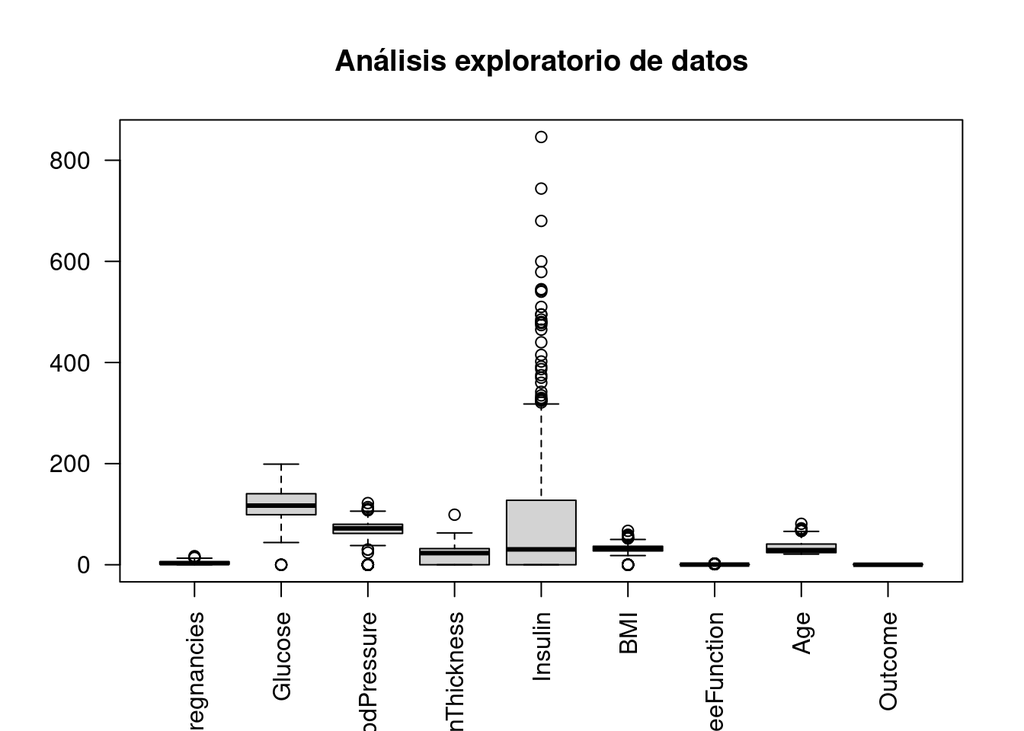

```r
par(mfrow=c(1,1))
boxplot(original_datos, main="Análisis exploratorio de datos", las=2)
```

Podemos ver los distintos outliers para cada variable representados por los circulos blancos. Vamos a sustituir estos outliers por la media de cada variable con el siguiente código:

```r
outlier2<-function(data,na.rm=T) {
  H<-1.5*IQR(data)

  data[data<quantile(data,0.25,na.rm = T)-H]<-NA

  data[data>quantile(data,0.75, na.rm = T)+H]<-NA

  data[is.na(data)]<-mean(data, na.rm = T)

  H<-1.5*IQR(data)

  if (TRUE %in% (data<quantile(data,0.25,na.rm = T)-H) | TRUE %in% (data>quantile(data,0.75,na.rm = T)+H))
    outlier2(data)
  else
    return(data)
}
```

```r
  for(i in 1:ncol(datos)){
    datos[,i] <- outlier2(datos[,i])
  }
```

Como podemos ver en el siguiente gráfico, se comparan los datos con outliers y sustituidos por su media:

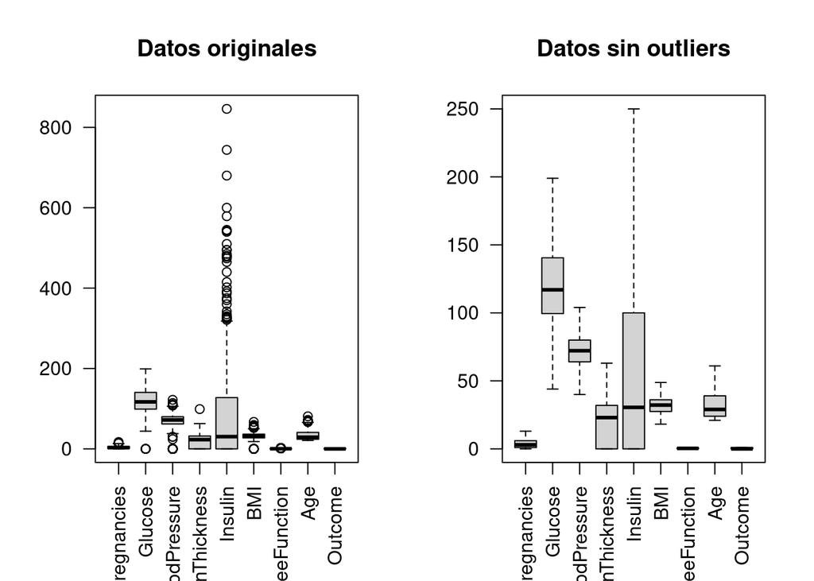

```r
  par(mfrow=c(1,2))
  boxplot(original_datos, main="Datos originales",las=2)
  boxplot(datos, main="Datos sin outliers",las=2)
```

## Análisis de la normalidad univariante

Vamos a estudiar la presencia de la distribución normal en cada de una de las variables de nuestros datos a través de distintas técnicas visuales y estadísticas.

### Distribuciones individuales

A continuación, vamos a mostrar un gráfico en el que para cada variable se ve un histograma con la información de esa variable y por encima, con una línea roja, una distribución normal con la media y desviación típica de cada variable, para ver cuánto se aproxima a la normalidad la distribución de los datos. Se observa que hemos eliminado la variable respuesta de este análisis porque no tiene sentido realizarlo en una variable discreta.

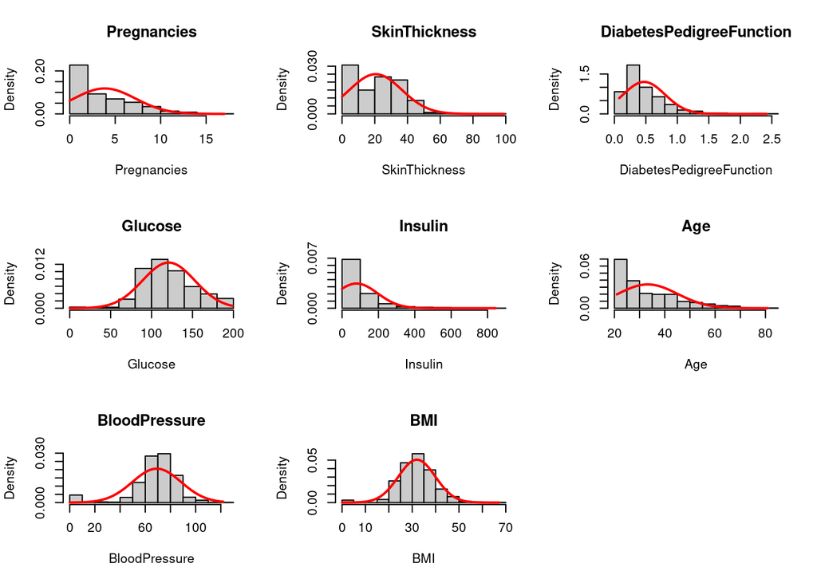

```r
# Representación mediante Histograma
par(mfcol = c(3, 3))
for (k in 1:ncol(datos_no_outcome)) {
  j0 <- names(datos_no_outcome)[k]
    x0 <- seq(min(datos_no_outcome[, k]), max(datos_no_outcome[, k]), le = 50)
    x <- datos_no_outcome[,k]
    hist(x, proba = T, col = grey(0.8), main = j0, xlab = j0)
    lines(x0, dnorm(x0, mean(x), sd(x)), col = "red", lwd = 2)
}
```

Como podemos observar, algunas variables sí se ajustan a la normalidad, pero solo por algunas zonas y muy pocas, con lo cual podemos intuir que nuestros datos no presentan normalidad.

### Gráficos qqplot

Otro método visual para detectar la normalidad son los gráficos qqplot.

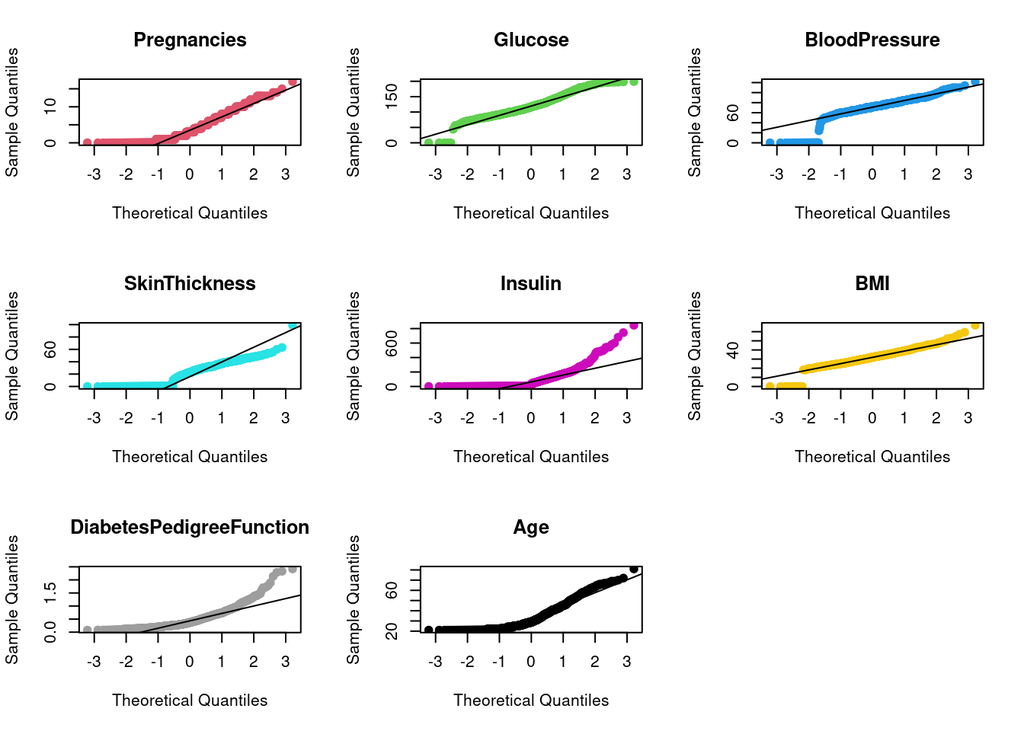

```r
# Representación de cuantiles normales de cada variable
par(mfrow=c(3,3))
for (k in 1:ncol(datos_no_outcome)) {
  j0 <- names(datos_no_outcome)[k]
  x <- datos_no_outcome[,k]
  qqnorm(x, main = j0, pch = 19, col=k+1)
  qqline(x)
}
```

De nuevo, en estos gráficos podemos observar que la linea se ajusta bien en algunas variables, pero solo en algunas zonas, con lo cual también podemos intuir por esté método visual que los datos no presentan normalidad.

Si bien este análisis exploratorio puede darnos una idea de la posible normalidad o no de las variables univariadas, siempre es mejor hacer los respectivos test de normalidad.

### Test de normalidad univariantes (Shapiro-Wilk)

```r
datos_tidy <- melt(datos_no_outcome, value.name = "valor", id.vars= NULL)
aggregate(valor~variable, data=datos_tidy, FUN = function(x){shapiro.test(x)$p.value})
```

```
##                   variable        valor
## 1              Pregnancies 1.609257e-21
## 2                  Glucose 1.986348e-11
## 3            BloodPressure 1.584162e-28
## 4            SkinThickness 1.751754e-21
## 5                  Insulin 7.914332e-34
## 6                      BMI 1.841652e-15
## 7 DiabetesPedigreeFunction 2.477506e-27
## 8                      Age 2.402274e-24
```

Como podemos observar en los resultados de este test, el p-valor es muy bajo para todas las variables, con lo cual **rechazamos la presencia de normalidad** univariante en nuestros datos.

# Análisis exploratorio multivariante

En este apartado, vamos a realizar un análisis de los datos pero estudiando todas las variables en su conjunto, utilizando diversas técnicas que iremos viendo en cada apartado.

## Análisis de la correlación

En primer lugar, vamos a estudiar la relación entre las variables, ya que si las variables no guardan ninguna correlación, no tendría sentido aplicar técnicas como ACP o AF, po lo que el primer paso es comprobar esto.

Primero, veamos la presencia de correlación gráficamente:

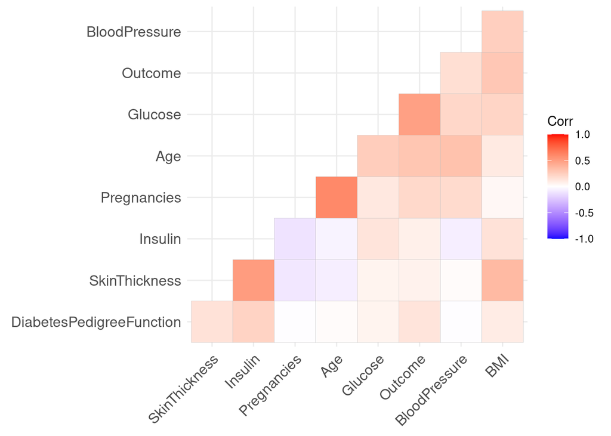

```r
poly_cor<-hetcor(datos)$correlations
ggcorrplot(poly_cor, type="lower",hc.order=T)
```

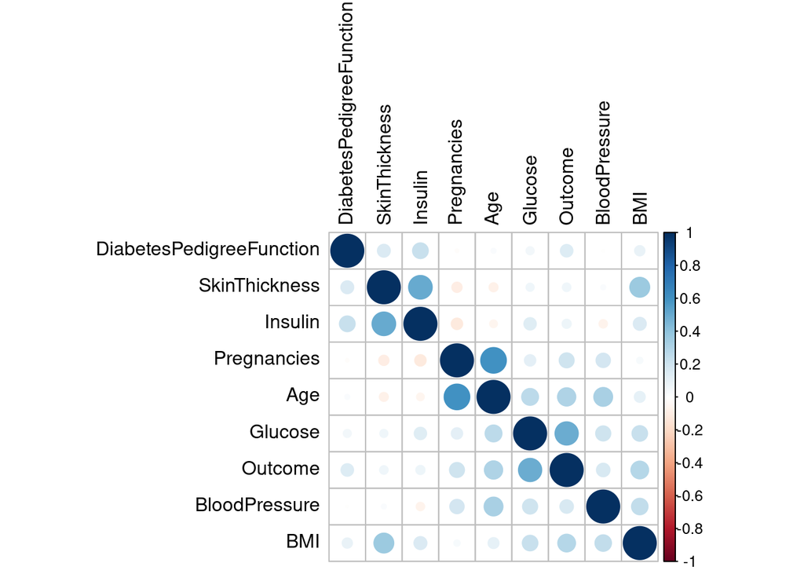

```r
par(mfrow=c(1,1))
corrplot(cor(datos), order = "hclust", tl.col='black', tl.cex=1)
```

Como podemos observar en ambos gráficos sí existe correlación entre las distintas variables, pero para afirmarlo es mejor utilizar el test correspondiente.

Pprocederemos con el test de Bartlett, el cual parte de la hipótesis nula de que la matriz de covarianzas es la identidad, esto es, las variables son independientes. Observamos también que para este test necesitamos hacerlo con los datos normalizados

```r
# Se hace el test de esfericidad
cortest.bartlett(cor(datos_normalizados), n = nrow(datos))
```

```
## $chisq
## [1] 948.2262
##
## $p.value
## [1] 1.25755e-181
##
## $df
## [1] 28
```

Como podemos observar, el test sale significativo y por ende la hipótesis nula que afirma que la matriz de correlaciones es la identidad queda descartada. Al haber relación entre las variables, tiene sentido plantearse análisis ACP o AF.

## Análisis de la normalidad multivariante

Al igual que hemos hecho en el apartado anterior vamos a analizar la normalidad presente en los datos, pero esta vez tratando a las variables en su conjunto como un vector aleatorio.

Vamos a realizar directamente el test correspondiente:

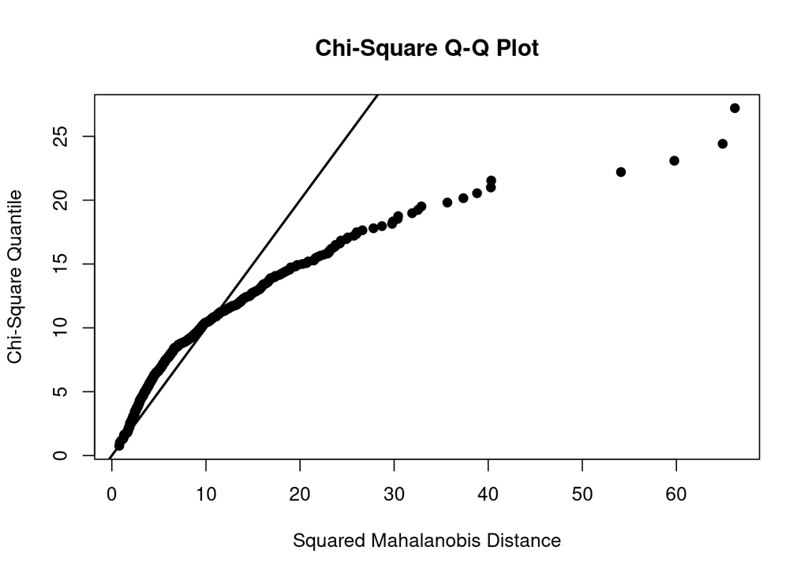

```r
royston_test <- mvn(data = datos_no_outcome, mvnTest = "royston", multivariatePlot = "qq")
```

```r
royston_test$multivariateNormality
```

```
##      Test        H       p value MVN
## 1 Royston 785.6488 2.839526e-164  NO
```

```r
hz_test <- mvn(data = datos_no_outcome, mvnTest = "hz")
hz_test$multivariateNormality
```

```
##            Test       HZ p value MVN
## 1 Henze-Zirkler 4.180486       0  NO
```

y como podemos observar el test sale significativo y como nos indica el propio resultado **no se presenta normalidad multivariante**.

## Reducción de la dimensión mediante un análisis de componentes principales

```r
# Realización del ACP
PCA<-prcomp(datos_no_outcome, scale=T, center = T)

# El campo "rotation" del objeto "PCA" es una matriz cuyas columnas
# son los coeficientes de las componentes principales, es decir, el
# peso de cada variable en la correspondiente componente principal
PCA$rotation
```

```
##                                 PC1        PC2         PC3         PC4
## Pregnancies              -0.1284321  0.5937858 -0.01308692  0.08069115
## Glucose                  -0.3930826  0.1740291  0.46792282 -0.40432871
## BloodPressure            -0.3600026  0.1838921 -0.53549442  0.05598649
## SkinThickness            -0.4398243 -0.3319653 -0.23767380  0.03797608
## Insulin                  -0.4350262 -0.2507811  0.33670893 -0.34994376
## BMI                      -0.4519413 -0.1009598 -0.36186463  0.05364595
## DiabetesPedigreeFunction -0.2706114 -0.1220690  0.43318905  0.83368010
## Age                      -0.1980271  0.6205885  0.07524755  0.07120060
##                                 PC5          PC6         PC7          PC8
## Pregnancies              -0.4756057  0.193598168 -0.58879003 -0.117840984
## Glucose                   0.4663280  0.094161756 -0.06015291 -0.450355256
## BloodPressure             0.3279531 -0.634115895 -0.19211793  0.011295538
## SkinThickness            -0.4878621  0.009589438  0.28221253 -0.566283799
## Insulin                  -0.3469348 -0.270650609 -0.13200992  0.548621381
## BMI                       0.2532038  0.685372179 -0.03536644  0.341517637
## DiabetesPedigreeFunction  0.1198105 -0.085784088 -0.08609107  0.008258731
## Age                      -0.1092900 -0.033357170  0.71208542  0.211661979
```

```r
# En el campo "sdev" del objeto "PCA" y con la función summary aplicada
# al objeto, obtenemos información relevante: desviaciones típicas de
# cada componente principal, proporción de varianza explicada y acumulada.
PCA$sdev
```

```
## [1] 1.4471973 1.3157546 1.0147068 0.9356971 0.8731234 0.8262133 0.6479322
## [8] 0.6359733
```

```r
summary(PCA)
```

```
## Importance of components:
##                           PC1    PC2    PC3    PC4     PC5     PC6     PC7
## Standard deviation     1.4472 1.3158 1.0147 0.9357 0.87312 0.82621 0.64793
## Proportion of Variance 0.2618 0.2164 0.1287 0.1094 0.09529 0.08533 0.05248
## Cumulative Proportion  0.2618 0.4782 0.6069 0.7163 0.81164 0.89697 0.94944
##                            PC8
## Standard deviation     0.63597
## Proportion of Variance 0.05056
## Cumulative Proportion  1.00000
```

Observamos la salida de esta orden, la cual nos realiza el ACP directamente. A continuación, obtenemos dos gráficos que representan la varianza explicada y acumulada para cada componente.

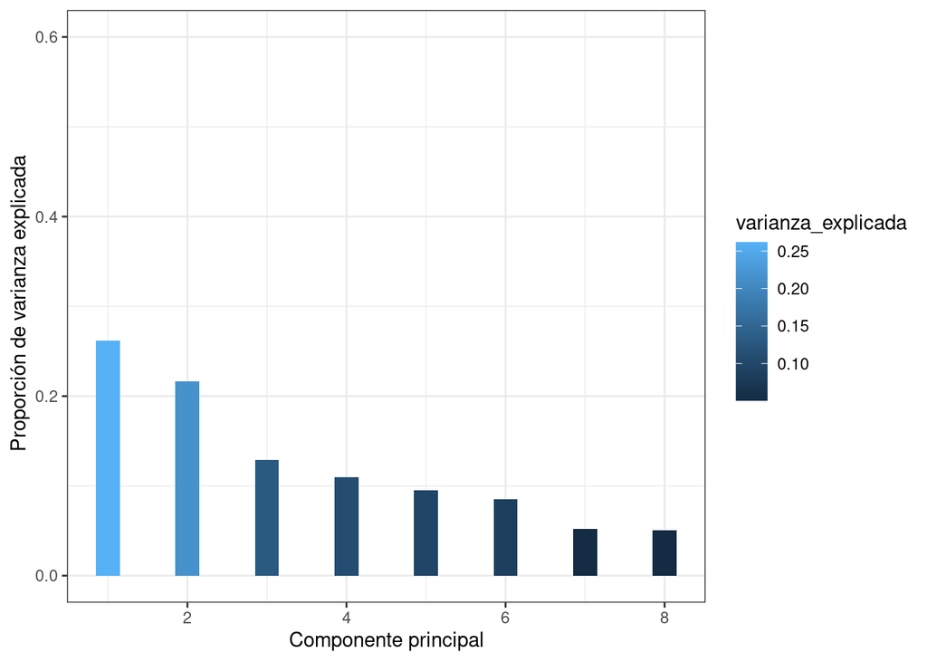

```r
par(mfrow=c(1,1))

# Proporción de varianza explicada
varianza_explicada <- PCA$sdev^2 / sum(PCA$sdev^2)
ggplot(data = data.frame(varianza_explicada, pc = 1:ncol(datos_no_outcome)),
       aes(x = pc, y = varianza_explicada, fill=varianza_explicada )) +
  geom_col(width = 0.3) +
  scale_y_continuous(limits = c(0,0.6)) + theme_bw() +
  labs(x = "Componente principal", y= " Proporción de varianza explicada")
```

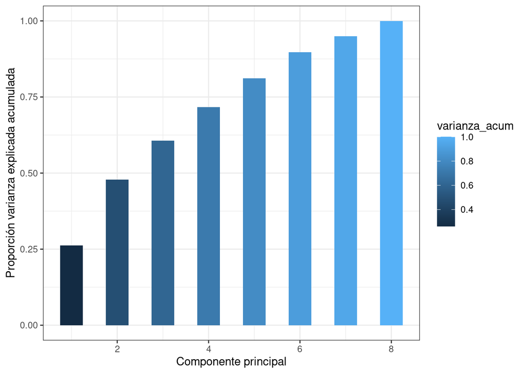

```r
# Proporción de varianza explicada acumulada
varianza_acum<-cumsum(varianza_explicada)
ggplot( data = data.frame(varianza_acum, pc = 1:ncol(datos_no_outcome)),
        aes(x = pc, y = varianza_acum ,fill=varianza_acum )) +
  geom_col(width = 0.5) +
  scale_y_continuous(limits = c(0,1)) +
  theme_bw() +
  labs(x = "Componente principal",
       y = "Proporción varianza explicada acumulada")
```

Ahora, debemos elegir cuántas componentes principales vamos a elegir. Utilizaremos la *Regla de Abdi* para ver la media de las varianzas explicadas por las componentes principales y seleccionar aquellas cuya proporción de varianza explicada supere a dicha media.

```r
PCA$sdev^2
```

```
## [1] 2.0943799 1.7312101 1.0296299 0.8755290 0.7623444 0.6826284 0.4198162
## [8] 0.4044620
```

```r
mean(PCA$sdev^2)
```

```
## [1] 1
```

La media es 1 y podemos observar que solo las 3 primeras componentes principales superan esta media, con lo cual obtenemos 3 componentes principales.

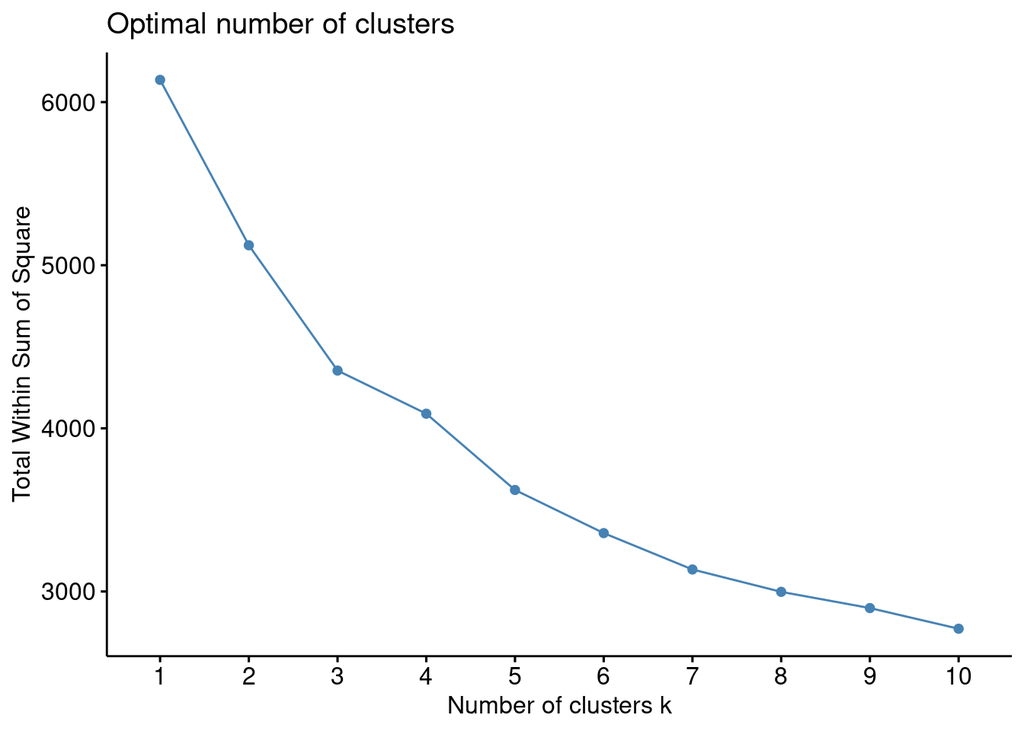

```r
fviz_nbclust(datos_normalizados, kmeans, method = 'wss')
```

## Reducción de la dimensión mediante un análisis factorial

Como ya hemos visto en el apartado anterior, tiene sentido plantear un análisis factorial. En primer lugar, vamos a obtener cuál sería el número idóneo de factores, realizando un Scree plot, el cual es una gráfica con los valores propios de la matriz policórica para quedarnos con los que son mayores que 1 y el número de factores es esa cantidad. También realizaremos un análisis paralelo que nos da el número de factores idóneo directamente.

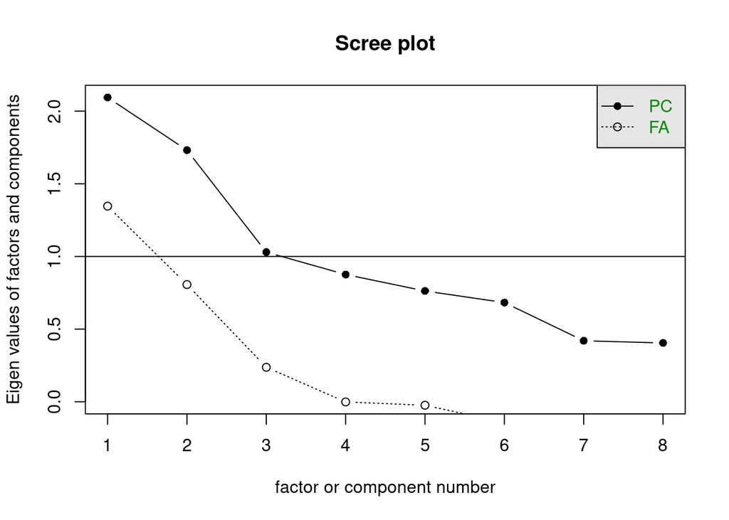

```r
poly_cor<-hetcor(datos_no_outcome)$correlations
scree(poly_cor)
```

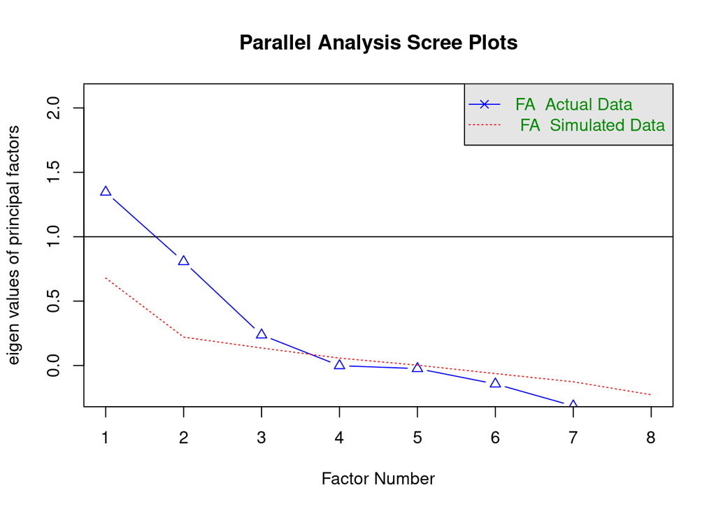

```
## Parallel analysis suggests that the number of factors =  3  and the number of components =  NA
```

```r
fa.parallel(poly_cor,n.obs=200,fa="fa",fm="minres")
```

Observando el gráfico y el resultado del análisis paralelo, el número óptimo de factores es 3, con lo cual vamos a crear los modelos con 3 factores:

```r
modelo1<-fa(poly_cor,
            nfactors = 3,
            rotate = "none",
            fm="mle") # modelo m?xima verosimilitud

modelo2<-fa(poly_cor,
            nfactors = 3,
            rotate = "none",
            fm="minres") # modelo m?nimo residuo
```

Por último, se comparan las comunalidades de cada modelo:

```r
sort(modelo1$communality,decreasing = T)->c1
sort(modelo2$communality,decreasing = T)->c2
head(cbind(c1,c2))
```

```
##                      c1        c2
## Glucose       0.9950001 1.0017373
## SkinThickness 0.8121893 0.8999630
## Age           0.7703578 0.5142209
## Pregnancies   0.3857519 0.3995173
## Insulin       0.3256899 0.3243878
## BMI           0.2329011 0.2139933
```

También comparamos las unicidades, es decir, la proporción de varianza que no ha sido explicada por el factor (1-comunalidad):

```r
sort(modelo1$uniquenesses,decreasing = T)->u1
sort(modelo2$uniquenesses,decreasing = T)->u2
head(cbind(u1,u2))
```

```
##                                 u1        u2
## DiabetesPedigreeFunction 0.9393351 0.9333588
## BloodPressure            0.8452669 0.7965446
## BMI                      0.7670989 0.7860067
## Insulin                  0.6743101 0.6756122
## Pregnancies              0.6142481 0.6004827
## Age                      0.2296422 0.4857791
```

## Análisis discriminante: Clasificadores

Finalmente, vamos a realizar un análisis discriminante, para poder obtener unos clasificadores en base a los datos que tenemos, para que se puedan realizar diagnosticos acerca de esta enfermedad. Vamos a realizar dos tipos de clasificadores, uno lineal y otro cuadrático:

### Clasificador lineal

```r
modelo_lda <- lda(formula = Outcome ~ Pregnancies + Glucose + BloodPressure + SkinThickness + Insulin + BMI + DiabetesPedigreeFunction + Age,data = datos)
modelo_lda
```

```
## Call:
## lda(Outcome ~ Pregnancies + Glucose + BloodPressure + SkinThickness +
##     Insulin + BMI + DiabetesPedigreeFunction + Age, data = datos)
##
## Prior probabilities of groups:
##         0         1
## 0.6510417 0.3489583
##
## Group means:
##   Pregnancies  Glucose BloodPressure SkinThickness  Insulin      BMI
## 0    3.298000 110.7101      70.79475      19.66400 52.13032 30.79349
## 1    4.698308 142.1656      74.59517      21.87102 62.93126 34.57407
##   DiabetesPedigreeFunction      Age
## 0                0.3879774 29.90435
## 1                0.4529204 36.32802
##
## Coefficients of linear discriminants:
##                                    LD1
## Pregnancies               0.0444029075
## Glucose                   0.0287884526
## BloodPressure            -0.0040980695
## SkinThickness            -0.0022288155
## Insulin                  -0.0003010238
## BMI                       0.0617628796
## DiabetesPedigreeFunction  1.0275757386
## Age                       0.0297898332
```

### Clasificador cuadrático

```r
modelo_qda <- qda(formula = Outcome ~ Pregnancies + Glucose + BloodPressure + SkinThickness + Insulin + BMI + DiabetesPedigreeFunction + Age,data = datos)
modelo_qda
```

```
## Call:
## qda(Outcome ~ Pregnancies + Glucose + BloodPressure + SkinThickness +
##     Insulin + BMI + DiabetesPedigreeFunction + Age, data = datos)
##
## Prior probabilities of groups:
##         0         1
## 0.6510417 0.3489583
##
## Group means:
##   Pregnancies  Glucose BloodPressure SkinThickness  Insulin      BMI
## 0    3.298000 110.7101      70.79475      19.66400 52.13032 30.79349
## 1    4.698308 142.1656      74.59517      21.87102 62.93126 34.57407
##   DiabetesPedigreeFunction      Age
## 0                0.3879774 29.90435
## 1                0.4529204 36.32802
```

## Resultados de los Clasificadores

```r
pred <- predict(modelo_lda, dimen = 1)
print("Matriz de confusión: ")
```

```
## [1] "Matriz de confusión: "
```

```r
confusionmatrix(datos$Outcome, pred$class)
```

```
##   new 0 new 1
## 0   441    59
## 1   116   152
```

```r
# Porcentaje de errores de clasificación
trainig_error <- mean(datos$Outcome != pred$class) * 100
paste("training_error=", trainig_error, "%")
```

```
## [1] "training_error= 22.7864583333333 %"
```

```r
pred <- predict(modelo_qda, dimen = 1)
print("Matriz de confusión: ")
```

```
## [1] "Matriz de confusión: "
```

```r
confusionmatrix(datos$Outcome, pred$class)
```

```
##   new 0 new 1
## 0   425    75
## 1    98   170
```

```r
# Porcentaje de errores de clasificación
trainig_error <- mean(datos$Outcome != pred$class) * 100
paste("training_error=", trainig_error, "%")
```

```
## [1] "training_error= 22.5260416666667 %"
```